# Assignment 1: Analyzing an Obesity dataset

William Schaafsma, Hau Nguyen, Qingyu Meng

19 mei, 2022

# 1 Introduction and Research Question

In this assignment an obesity dataset, retrieved from [Palechor & Manotas, 2019](https://www-sciencedirect-com.proxy.library.uu.nl/science/article/pii/S2352340919306985?via%3Dihub) will be analyzed. The data gathered for this paper comes from individuals that live in Peru, Mexico and Colombia. It’s stated that 23% of the data is “real” and that 77% has been synthetically generated.

The goal for this assignment is to build a model that most accurately predicts the BMI of *new* patients. Understanding which predictors have great influence for one’s BMI is favorable for policymakers regarding national health. Moreover, patients get more understanding of their own health.

We will work in an exploratory manner. Thus, in this assignment we are particularly interested in: ‘What predictors show the greatest influence regarding a person’s BMI?’

# 2 Packages

The following libraries are required to run this program succesfully.

```r
library(ggplot2)
library(corrplot)
library(dplyr)
library(knitr)
library(tidyverse)
library(mice)
library(magrittr)
library(readr)
library(caret)
library(leaps)
```

# 3 Loading the dataset & set seed

First we load the data and set the seed in order to generate a reproducible result.

```r
# loading data
obese <- read_csv("ObesityDataSet_raw_and_data_sinthetic (2)/ObesityDataSet_raw_and_data_sinthetic.csv")

# set the seed
set.seed(1705)
```

# 4 Processing of the data

We want to include BMI as a dependent variable in our model. Thus we have to derive BMI from Weight and Height with the formula: $BMI = Weight / Height^2$

```r
# calculating bmi from height and weight
Bmi <- data.frame(Bmi = (obese$Weight / (obese$Height^2)))

# adding bmi to the original dataframe
obese_mid <- cbind(obese, Bmi)

# removing *NObeyesdad* since we don't need the variable
obese_complete <- select(obese_mid, -NObeyesdad)
```

# 5 Splitting the data into train, validation & test

In order to evaluate the performance of the model we will build later on, we have to split the data into three partitions: Train, Test, Validation. The data will be split in a way that ~70% of the data is used for training the model, ~20% for validating the model and ~10% for testing the model.

```r
# partition of training
part_train <- createDataPartition(obese_complete$Bmi, p = .7,
                                  list = FALSE,
                                  times = 1)

# creation of training data
obese_train <- obese_complete[part_train,]

# remainder for validation and testing
part_test_val <- obese_complete[-part_train,]

# partition of validation
part_val <- createDataPartition(part_test_val$Bmi, p = .66,
                                  list = FALSE,
                                  times = 1)
# creation of validation data
obese_val <- part_test_val[part_val,]

# creation of test data
obese_test  <- part_test_val[-part_val,]
```

# 6 Explaining the variables

**WARNING:** the simulated data created incorrect data. Particularly, it treated categorical data as numeric data and therefore wrongfully imputed these data. However, in this assignment we will treat these data as if they were numeric since converting the datatypes causes loads of parsing errors. This problem affects the following variables: *FCVC, NCP, CH2O, FAF* and *TUE*.

In this section, an elaboration on the variables is given. For starters, the categorical variable **Gender** consists of two categories representing one’s gender: male or female.

Then the continuous variable **Height** that contains floating values for a person’s Height, measured in meters.

Then there’s another continuous variable **Weight** that also contains floating values for a person’s weight, measured in Kilograms (KG).

There’s also the dichotomous variable **family_history_with_overweight** which controls for possible genetic predisposition for a high BMI.

Next is another dichotomous variable **FAVC** that represents whether a person frequently consumes high caloric foods.

Then a “numeric” variable **FCVC** which represents the frequency of consuming vegetables.

Then there’s another “numeric” variable **NCP** that accounts for the number of main meals each day.

Next is the categorical variable **CAEC** consisting of four categories representing the consumption of foods between meals: No, Sometimes, Frequently, Always.

Then there is a dichotomous variable **SMOKE** that represents whether a person smokes

Next is a “numeric” variable **CH2O** which represents the amount of water a person drinks each day.

Next is another dichotomous variable **SCC** that accounts for calorie checking.

Then there’s a “numeric” variable **FAF** which represents the frequency of physical activity of a person.

Next is another “numeric” variable **TUE** which represents the amount a person spends on it’s devices such as a phone.

Then there is the categorical variable **CALC** consisting of four categories representing a person’s alcohol intake: Nothing, Sometimes, Frequently, Always.

Finally, there is the categorical variable **MTRANS** consisting of five categories representing a person’s most used public transport: Automobile, Motorbike, Bike, Public Transportation and Walking.

# 7 Getting to know the data

In order to work with a dataset, we need to understand the dataset. First, let’s check wether there are missing data in our dataset. To do this we use the `mice` package.

```r
md.pattern(obese_complete)
```

```
##  /\     /\
## {  `---'  }
## {  O   O  }
## ==>  V <==  No need for mice. This data set is completely observed.
##  \  \|/  /
##   `-----'
```

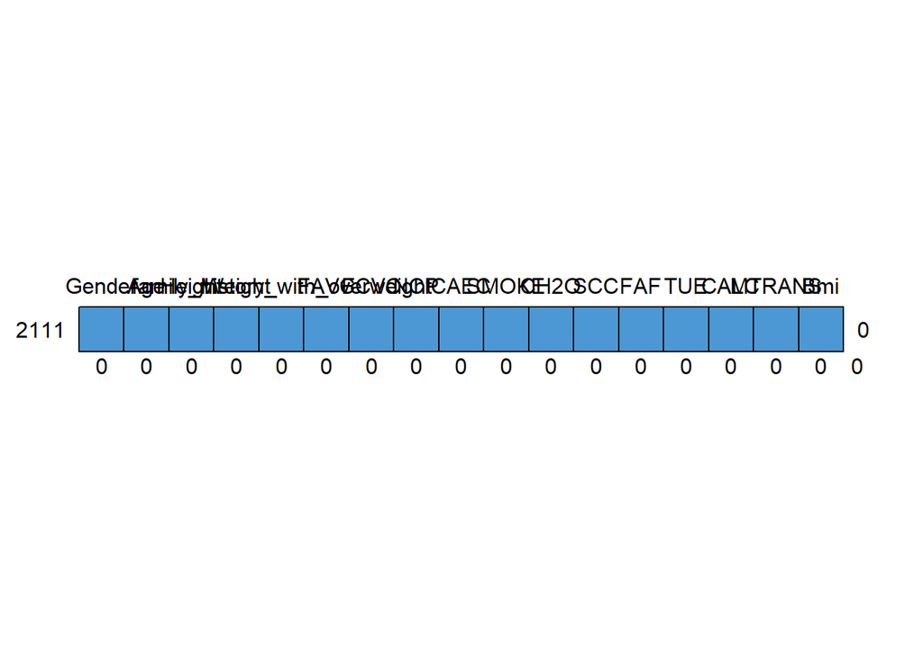

```
##      Gender Age Height Weight family_history_with_overweight FAVC FCVC NCP CAEC
## 2111      1   1      1      1                              1    1    1   1    1
##           0   0      0      0                              0    0    0   0    0
##      SMOKE CH2O SCC FAF TUE CALC MTRANS Bmi
## 2111     1    1   1   1   1    1      1   1 0
##          0    0   0   0   0    0      0   0 0
```

Fortunately, we can conclude that our dataset contains no missing values. Furthermore, the figure shows that our dataset holds 17 variables and 2111 observations.

Now, let us see the head and the summary of the dataset

```r
head(obese_complete) %>%
  knitr::kable(format = "markdown", digits= 1, padding = 30, align = 'c')
```

| Gender | Age | Height | Weight | family_history_with_overweight | FAVC | FCVC | NCP | CAEC | SMOKE | CH2O | SCC | FAF | TUE | CALC | MTRANS | Bmi |
| --- | --- | --- | --- | --- | --- | --- | --- | --- | --- | --- | --- | --- | --- | --- | --- | --- |
| Female | 21 | 1.6 | 64.0 | yes | no | 2 | 3 | Sometimes | no | 2 | no | 0 | 1 | no | Public_Transportation | 24.4 |
| Female | 21 | 1.5 | 56.0 | yes | no | 3 | 3 | Sometimes | yes | 3 | yes | 3 | 0 | Sometimes | Public_Transportation | 24.2 |
| Male | 23 | 1.8 | 77.0 | yes | no | 2 | 3 | Sometimes | no | 2 | no | 2 | 1 | Frequently | Public_Transportation | 23.8 |
| Male | 27 | 1.8 | 87.0 | no | no | 3 | 3 | Sometimes | no | 2 | no | 2 | 0 | Frequently | Walking | 26.9 |
| Male | 22 | 1.8 | 89.8 | no | no | 2 | 1 | Sometimes | no | 2 | no | 0 | 0 | Sometimes | Public_Transportation | 28.3 |
| Male | 29 | 1.6 | 53.0 | no | yes | 2 | 3 | Sometimes | no | 2 | no | 0 | 0 | Sometimes | Automobile | 20.2 |

```r
summary(obese_complete)
```

```
##     Gender               Age            Height          Weight
##  Length:2111        Min.   :14.00   Min.   :1.450   Min.   : 39.00
##  Class :character   1st Qu.:19.95   1st Qu.:1.630   1st Qu.: 65.47
##  Mode  :character   Median :22.78   Median :1.700   Median : 83.00
##                     Mean   :24.31   Mean   :1.702   Mean   : 86.59
##                     3rd Qu.:26.00   3rd Qu.:1.768   3rd Qu.:107.43
##                     Max.   :61.00   Max.   :1.980   Max.   :173.00
##  family_history_with_overweight     FAVC                FCVC
##  Length:2111                    Length:2111        Min.   :1.000
##  Class :character               Class :character   1st Qu.:2.000
##  Mode  :character               Mode  :character   Median :2.386
##                                                    Mean   :2.419
##                                                    3rd Qu.:3.000
##                                                    Max.   :3.000
##       NCP            CAEC              SMOKE                CH2O
##  Min.   :1.000   Length:2111        Length:2111        Min.   :1.000
##  1st Qu.:2.659   Class :character   Class :character   1st Qu.:1.585
##  Median :3.000   Mode  :character   Mode  :character   Median :2.000
##  Mean   :2.686                                         Mean   :2.008
##  3rd Qu.:3.000                                         3rd Qu.:2.477
##  Max.   :4.000                                         Max.   :3.000
##      SCC                 FAF              TUE             CALC
##  Length:2111        Min.   :0.0000   Min.   :0.0000   Length:2111
##  Class :character   1st Qu.:0.1245   1st Qu.:0.0000   Class :character
##  Mode  :character   Median :1.0000   Median :0.6253   Mode  :character
##                     Mean   :1.0103   Mean   :0.6579
##                     3rd Qu.:1.6667   3rd Qu.:1.0000
##                     Max.   :3.0000   Max.   :2.0000
##     MTRANS               Bmi
##  Length:2111        Min.   :13.00
##  Class :character   1st Qu.:24.33
##  Mode  :character   Median :28.72
##                     Mean   :29.70
##                     3rd Qu.:36.02
##                     Max.   :50.81
```

From the head and summary function we can tell that the data has loaded as expected and that the datatypes are in line with how we described them in section **“Explaining the variables”**.

# 8 Correlations

# 9 Model training

For the sake of model training we will start by a simple linear model that contains just one predictor. In this case we will pick the variable *Age*.

```r
model_1 <- lm(Bmi ~ Age, data = obese_train)
summary(model_1)
```

```
##
## Call:
## lm(formula = Bmi ~ Age, data = obese_train)
##
## Residuals:
##     Min      1Q  Median      3Q     Max
## -17.896  -5.743  -1.321   5.362  22.118
##
## Coefficients:
##             Estimate Std. Error t value Pr(>|t|)
## (Intercept) 22.37868    0.79788  28.048   <2e-16 ***
## Age          0.29990    0.03173   9.451   <2e-16 ***
## ---
## Signif. codes:  0 '***' 0.001 '**' 0.01 '*' 0.05 '.' 0.1 ' ' 1
##
## Residual standard error: 7.736 on 1477 degrees of freedom
## Multiple R-squared:  0.05703,    Adjusted R-squared:  0.05639
## F-statistic: 89.32 on 1 and 1477 DF,  p-value: < 2.2e-16
```

```r
model_2 <- lm(Bmi ~ Age + CALC + FAVC + family_history_with_overweight, data = obese_train)
summary(model_2)
```

```
##
## Call:
## lm(formula = Bmi ~ Age + CALC + FAVC + family_history_with_overweight,
##     data = obese_train)
##
## Residuals:
##      Min       1Q   Median       3Q      Max
## -18.1642  -5.1759   0.1674   4.3681  18.4330
##
## Coefficients:
##                                    Estimate Std. Error t value Pr(>|t|)
## (Intercept)                       12.779468   1.232636  10.368  < 2e-16 ***
## Age                                0.182535   0.027588   6.617 5.13e-11 ***
## CALCno                             0.009857   0.973645   0.010    0.992
## CALCSometimes                      3.962379   0.946900   4.185 3.03e-05 ***
## FAVCyes                            2.948743   0.538744   5.473 5.18e-08 ***
## family_history_with_overweightyes  8.844645   0.462948  19.105  < 2e-16 ***
## ---
## Signif. codes:  0 '***' 0.001 '**' 0.01 '*' 0.05 '.' 0.1 ' ' 1
##
## Residual standard error: 6.565 on 1473 degrees of freedom
## Multiple R-squared:  0.3226, Adjusted R-squared:  0.3203
## F-statistic: 140.3 on 5 and 1473 DF,  p-value: < 2.2e-16
```

# 10 Best model selection & model comparison

Building a model by trial and error takes a lot of time and working memory. It’s best to build a model based on some algorithm. For example we can use *forward selection*. This method start with no predictors and then iteratively adds contributive predictors untill there’s no significant improvement.

```r
# start building a model by forward selection
model_forward <- regsubsets(Bmi ~., data = obese_train,
                                 method = "forward")

summary(model_forward)
```

```
## Subset selection object
## Call: regsubsets.formula(Bmi ~ ., data = obese_train, method = "forward")
## 22 Variables  (and intercept)
##                                   Forced in Forced out
## GenderMale                            FALSE      FALSE
## Age                                   FALSE      FALSE
## Height                                FALSE      FALSE
## Weight                                FALSE      FALSE
## family_history_with_overweightyes     FALSE      FALSE
## FAVCyes                               FALSE      FALSE
## FCVC                                  FALSE      FALSE
## NCP                                   FALSE      FALSE
## CAECFrequently                        FALSE      FALSE
## CAECno                                FALSE      FALSE
## CAECSometimes                         FALSE      FALSE
## SMOKEyes                              FALSE      FALSE
## CH2O                                  FALSE      FALSE
## SCCyes                                FALSE      FALSE
## FAF                                   FALSE      FALSE
## TUE                                   FALSE      FALSE
## CALCno                                FALSE      FALSE
## CALCSometimes                         FALSE      FALSE
## MTRANSBike                            FALSE      FALSE
## MTRANSMotorbike                       FALSE      FALSE
## MTRANSPublic_Transportation           FALSE      FALSE
## MTRANSWalking                         FALSE      FALSE
## 1 subsets of each size up to 8
## Selection Algorithm: forward
##          GenderMale Age Height Weight family_history_with_overweightyes FAVCyes
## 1  ( 1 ) " "        " " " "    "*"    " "                               " "
## 2  ( 1 ) " "        " " "*"    "*"    " "                               " "
## 3  ( 1 ) " "        " " "*"    "*"    "*"                               " "
## 4  ( 1 ) " "        " " "*"    "*"    "*"                               " "
## 5  ( 1 ) " "        " " "*"    "*"    "*"                               " "
## 6  ( 1 ) " "        " " "*"    "*"    "*"                               " "
## 7  ( 1 ) " "        " " "*"    "*"    "*"                               "*"
## 8  ( 1 ) " "        " " "*"    "*"    "*"                               "*"
##          FCVC NCP CAECFrequently CAECno CAECSometimes SMOKEyes CH2O SCCyes FAF
## 1  ( 1 ) " "  " " " "            " "    " "           " "      " "  " "    " "
## 2  ( 1 ) " "  " " " "            " "    " "           " "      " "  " "    " "
```

[output cut: 9 more lines]

```
## 3  ( 1 ) " " " "    " "           " "        " "
## 4  ( 1 ) " " " "    " "           " "        " "
## 5  ( 1 ) " " " "    " "           " "        " "
## 6  ( 1 ) " " " "    " "           " "        " "
## 7  ( 1 ) " " " "    " "           " "        " "
## 8  ( 1 ) " " " "    "*"           " "        " "
##          MTRANSPublic_Transportation MTRANSWalking
## 1  ( 1 ) " "                         " "
## 2  ( 1 ) " "                         " "
## 3  ( 1 ) " "                         " "
## 4  ( 1 ) " "                         " "
## 5  ( 1 ) " "                         " "
## 6  ( 1 ) " "                         " "
## 7  ( 1 ) " "                         " "
## 8  ( 1 ) " "                         " "
```

# 11 Model evaluation & VIF

# 12 Checking assumptions

# 13 Visualizations

# 14 Answering research question

# 15 Discussion & Limitations

# 16 Sources